# Get more experience with R

Group XX

14 March, 2025

# Introduction

In this R-challenge we would first like to reproduce a volcano plot from an article using the provided supplementary data and then apply some of the skills we have learned in the previous weeks. Basically, in the same article, the authors also provide a matrix with the expression of the proteins in the surfaceome of multiple myeloma cells. We will try to visualize this matrix as a heatmap, a correlation heatmap or a PCA/MDS plot.

**Article: The surfaceome of multiple myeloma cells suggests potential immunotherapeutic strategies and protein markers of drug resistance** DOI: 10.1038/s41467-022-31810-6

The article “The surfaceome of multiple myeloma cells suggests potential immunotherapeutic strategies and protein markers of drug resistance” by Ferguson et al. presents a comprehensive investigation of the surface proteome, or surfaceome, of multiple myeloma cells. This study is pivotal as it explores how the surfaceome influences the interaction between tumor cells and their microenvironment, making it a critical area for potential therapeutic advancements and understanding drug resistance mechanisms (Ferguson et al. 2022).

The authors employed glycoprotein capture proteomics to systematically characterize the myeloma surfaceome under various conditions: at baseline, when facing drug resistance, and in response to acute drug treatments. This methodology allowed for a detailed examination of surface antigens that could be targeted for immunotherapy. The findings from this study include the establishment of a scoring system to evaluate and prioritize these surface antigens based on their potential therapeutic value (Ferguson et al. 2022).

One of the most significant outcomes of the study is the identification of CCR10 as a promising target for immunotherapeutic intervention. The expression of CCR10 was noted to be prevalent among malignant plasma cells, suggesting that therapies targeting this marker could enhance treatment efficacy. This provides a strategic direction for developing new immunotherapies aimed specifically at overcoming the challenges associated with drug resistance in multiple myeloma (Ferguson et al. 2022).

Overall, the article provides vital insights into the complexity of the myeloma surfaceome and reinforces the need for continued exploration into targeted therapies that can improve clinical outcomes in patients suffering from multiple myeloma. *the article (pdf) is available in the folder of this tutorial*

## Libraries used for this tutorial:

You may not need all of these listed here.

- tidyr, dplyr: data handling from the tidyverse
- magrittr: together with tidyverse it allows the use of %<>%
- readxl and openxlsx: libraries to open and write microsoft excel files
- ggplot2: produce nice plots
- pheatmap: to great nice (pretty) heatmaps from matrices
- ggtree: to plot phylogenetic trees
- ape: to read and manipulate phylogenetic trees
- viridis: to get nice color scales
- DESeq2, plotly, limma, SummarizedExperiment: to generate similar QC plots as in week 2
- ggrepel: to avoid overplotting of labels in ggplot2

## Idea in this R-challenge:

- Find the excel sheet, look at it, see what is relevant and then try to do the coding
- One sheet in this excel book is relevant but only part of it, try to restructure it R the way you need it
- Try to use AI in this challenge at multiple steps (restructure the data, plotting w/ ggplot) if it is not immediately obvious to you how to do it.

# Goal 1: Redo Figure 1E from the article

Below here we show the Figure 1E from the article. We will try to reproduce this figure with the data provided in as supplement in an excel file. *Try first to understand what this plot is showing. And explain it here, also indicate what columns are potentially relevant in this sheet (not all of them you need to use). Something like: on this volcano we see ..*

```r
#Proteins expressed on MM cells more often than ALL cells on the right (+ve values for log2 fold-change). Y-axis is how statistically significant the differential expression is.
```

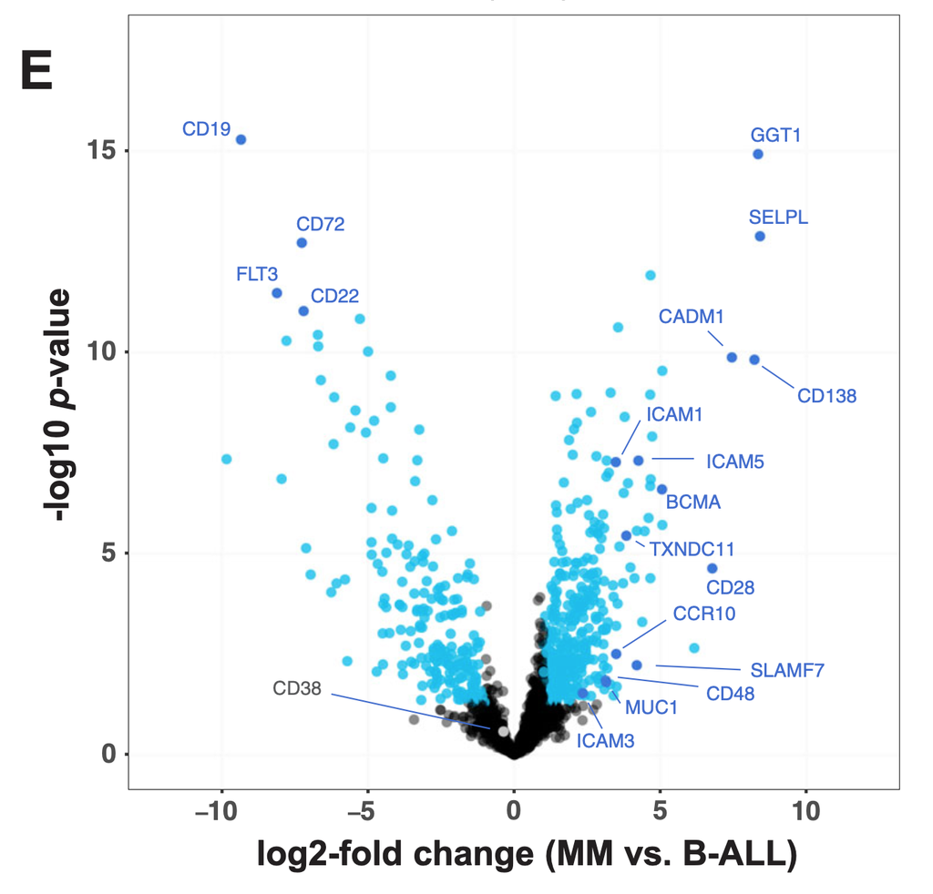

NatCom: Ferguson et. al, Figure 1E

```
## # A tibble: 6 × 44
##   Uniprot_ID AMO1.1 AMO1.2 AMO1.3 ARH77.WT.1 ARH77.WT.2 ARH77.WT.3 Bcell.1
##   <chr>       <dbl>  <dbl>  <dbl>      <dbl>      <dbl>      <dbl>   <dbl>
## 1 Q14242       28.7   30.8   30.2       26.6       27.7       26.9    25.3
## 2 P19440       29.7   30.9   30.3       28.6       28.1       28.6    28.0
## 3 P18827       33.7   32.3   32.7       24.3       27.7       25.7    27.9
## 4 Q9BY67       28.0   26.0   27.5       22.2       19.2       21.6    24.3
## 5 P10747       29.9   29.1   27.9       20.1       22.0       21.1    20.8
## 6 Q12860       19.7   20.1   19.4       29.1       28.8       29.9    24.1
## # ℹ 36 more variables: Bcell.2 <dbl>, Bcell.3 <dbl>, BEL.1 <dbl>, BEL.2 <dbl>,
## #   BEL.3 <dbl>, KMS12.1 <dbl>, KMS12.2 <dbl>, KMS12.3 <dbl>, KOPN8.1 <dbl>,
## #   KOPN8.2 <dbl>, KOPN8.3 <dbl>, L363.WT.1 <dbl>, L363.WT.2 <dbl>,
## #   REH.1 <dbl>, REH.2 <dbl>, REH.3 <dbl>, RPMI.1 <dbl>, RPMI.2 <dbl>,
## #   RPMI.3 <dbl>, RS411.1 <dbl>, RS411.2 <dbl>, RS411.3 <dbl>, SUP.1 <dbl>,
## #   SUP.2 <dbl>, SUP.3 <dbl>, TOM.1 <dbl>, TOM.2 <dbl>, TOM.3 <dbl>,
## #   `Average Myeloma LFQ` <dbl>, Protein <chr>, Fasta.headers <chr>, …
```

```
## # A tibble: 6 × 2
##   X_axis   Y_axis
##    <dbl>    <dbl>
## 1   8.41 1.30e-13
## 2   8.34 1.18e-15
## 3   8.22 1.51e-10
## 4   7.45 1.33e-10
## 5   6.77 2.31e- 5
## 6   6.16 2.23e- 3
```

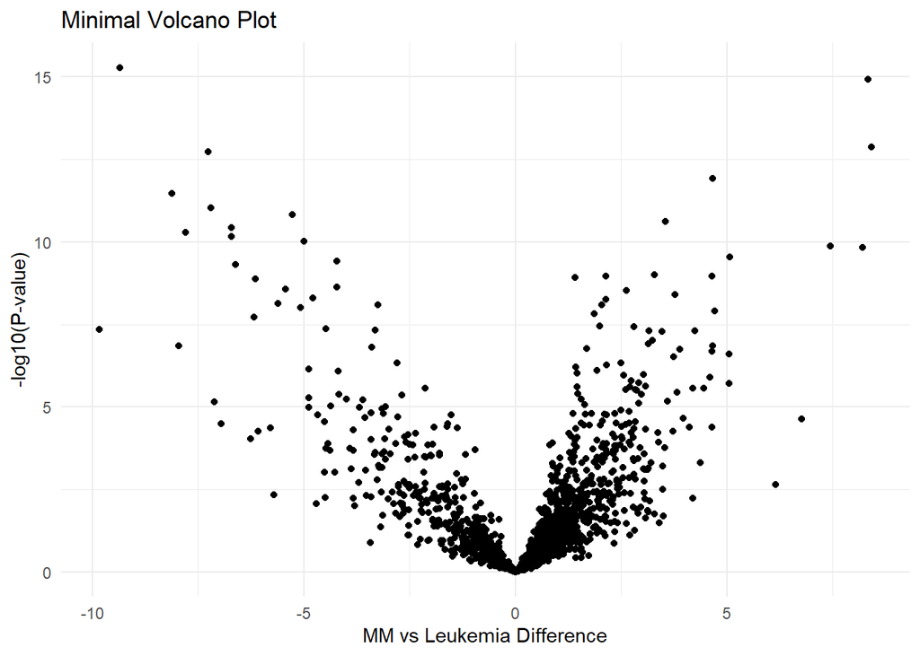

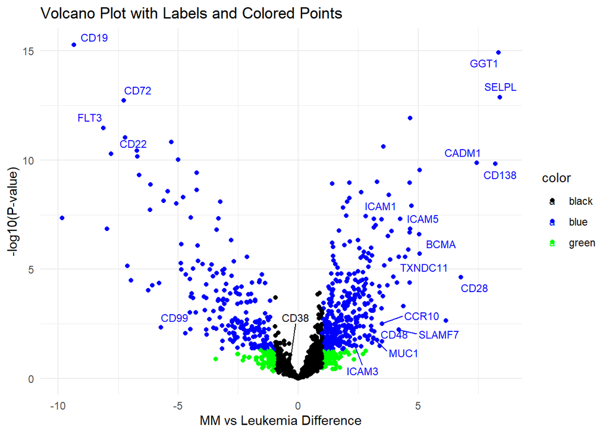